# Wald vs likelihood ratio tests: examples

Author

Ben Bolker

Published

September 28, 2026

Exploring (with Claude …) the properties of Wald p-values (via `car::Anova()`) and likelihood ratio tests [LRT] (via `drop1()`): in particular, type-I error/coverage.

**tl;dr** there is surprisingly (to me) little difference in type-I error between Wald and LRT for sensible cases, although presumably we could find some if we tried hard enough. Coverage[^1] of confidence intervals for non-null cases shows bigger (but still surprisingly small) differences. The report explores that case for logistic regression, but the results are complicated. Logistic regression estimates are biased for small $n$; this effect fights with the conservatism of Wald CIs due to Hauck-Donner effects (Hauck and Donner 1977). In the logistic case we also explore variant estimators that shrink the estimates toward zero (Firth/Jeffreys prior, $t$ prior), which mitigate upward small-sample bias of the MLE when the effects are moderate but lead to downward bias (by overcorrecting) when the effects are large …

Even so, the advantages of the LRT/profile confidence intervals have more to do with power and interval shape than with type-I error/coverage. Over a sensible range of effect sizes for the binomial (say $0 \le \beta < 4$), with baseline probability $p_0 = 0.2$ and $n = 50$ or 100 per group, both methods get two-tailed coverage within about 0.02 of nominal, partly because some directional biases cancel out for the Wald CIs. (The patterns of one-sided coverage are more interesting/complicated.) With $n = 20$ per group, Wald is conservative, while the unpenalized LRT is anticonservative for $\beta$ up to about 4.5–5 (worst around $\beta = 3.5$, where the coverage drops to about 0.90) and conservative beyond that.

```r
library(glmmTMB)
library(car)
library(tidyverse)
library(futurize)
library(patchwork)

## avoid overcommitting threads
library(RhpcBLASctl)
blas_set_num_threads(1)
omp_set_num_threads(1)

## adjust this to something that makes sense on your machine (memory
## as well as cores), or set the WALD_WORKERS environment variable
nworkers <- as.integer(Sys.getenv("WALD_WORKERS",
                                  min(28, parallel::detectCores() - 1)))
plan(multicore, workers = nworkers)

theme_set(theme_bw())
zmargin <- theme(panel.spacing = grid::unit(0, "pt"))
## Okabe-Ito minus black and yellow
oi_cols <- c("#E69F00", "#56B4E9", "#009E73", "#0072B2", "#D55E00", "#CC79A7")
scale_colour_discrete <- function(...) scale_colour_manual(..., values = oi_cols)

## functions shared with wald_lrt_examples_lowp.R: the empty chunks
## below with matching labels get their code from here
knitr::read_chunk("wald_lrt_funs.R")
```

## Negative binomial GLMM: type I error under the null

Original example from Christoph Scherber: compare `drop1()` (likelihood ratio test) and `car::Anova()` (Wald test) for the species effect in a zero-inflated negative binomial GLMM.

```r
m2 <- glmmTMB(count ~ spp + mined + (1|site),
   zi=~spp + mined,
   family=nbinom2, data=Salamanders)
drop1(m2,test="Chisq")
```

```
Single term deletions

Model:
count ~ spp + mined + (1 | site)
       Df    AIC    LRT  Pr(>Chi)
<none>    1670.3
spp     6 1685.9 27.630 0.0001103 ***
mined   1 1685.4 17.097 3.552e-05 ***
---
Signif. codes:  0 '***' 0.001 '**' 0.01 '*' 0.05 '.' 0.1 ' ' 1
```

```r
Anova(m2)
```

```
Analysis of Deviance Table (Type II Wald chisquare tests)

Response: count
       Chisq Df Pr(>Chisq)
spp   24.682  6   0.000391 ***
mined 15.202  1  9.661e-05 ***
---
Signif. codes:  0 '***' 0.001 '**' 0.01 '*' 0.05 '.' 0.1 ' ' 1
```

```r
## extract drop1 (LRT) and Anova (Wald) p-values
get_p_values <- function(model, w = 1) {
  d <- drop1(model, test="Chisq")
  p_drop <- d[["Pr(>Chi)"]][[w+1]]
  a <- Anova(model)
  p_anova <- a[["Pr(>Chisq)"]][[w]]
  tibble(p_drop, p_anova)
}

## simplified null-hypothesis simulation (no zi);
## species effect (fixed effects parameters 2-7) is set to zero
simfun <- function(n = nrow(Salamanders)) {
    dd <- transform(Salamanders,
            count = simulate_new(~ spp + mined + (1|site),
            newdata = Salamanders,
            newparams = list(beta = c(-0.5, rep(0,6), 1.4),
            betadisp = 0.5,
            theta = -1),
            family = nbinom2)[[1]])
    ## randomly subsample (sorting isn't strictly necessary)
    dd <- dd[sort(sample(nrow(Salamanders), size = n)), ]
    return(dd)
}

fitfun <- function(data = simfun()) {
  model <- glmmTMB(count ~ spp + mined + (1|site),
                   family=nbinom2, data=data)
  return(model)
}

sumfun <- function(model = fitfun()) {
  get_p_values(model)
}

full_sim <- function(n = nrow(Salamanders), nsim = 1000, seed = 101) {
  set.seed(seed)
  tt <- system.time(
    res <- replicate(nsim, sumfun(fitfun(simfun(n = n))), simplify = FALSE) |>
      futurize() |>
      bind_rows()
  )
  attr(res, "time") <- tt
  res
}

rpt_time <- function(x) { attr(x, "time")[["elapsed"]] |> round() }
```

Type I error for the full data set (n = 644) and for random subsamples of size 100:

```r
res <- full_sim()
```

```r
res_small <- full_sim(n = 100)
```

A few fits to the subsampled data have non-positive-definite Hessians, giving NA p-values; these are dropped (`n_na` counts them).

```r
nb_sum <- function(r) {
  c(colMeans(r < 0.05, na.rm = TRUE), n_na = sum(!complete.cases(r)))
}
bind_rows(full = nb_sum(res),
          n100 = nb_sum(res_small),
          .id = "sample")
```

```
# A tibble: 2 × 4
  sample p_drop p_anova  n_na
  <chr>   <dbl>   <dbl> <dbl>
1 full   0.056    0.055     0
2 n100   0.0791   0.095     1
```

(The simulations take 160 and 89 seconds, respectively, on 28 cores on my machine)

There is very little difference between the tests in this case, and at n = 100 both are somewhat anticonservative. The Wald and LRT are asymptotically equivalent under the null, so a null location effect with a reasonable sample size/signal-to-noise ratio is a friendly case for the Wald test; both tests have slightly inflated type-I errors in the small sample case.

The bigger differences are in coverage and power for non-null cases.

## Binomial example

Two-group logistic regression (baseline probability 0.2, 20, 50 or 100 per group); the log-odds ratio ($\beta$) ranges from 0 (null) to large values, where the second group’s probability approaches 1 and the log-likelihood becomes strongly asymmetric (Hauck-Donner territory). With a sparser baseline (e.g. 0.05) the LRT itself becomes anticonservative under the null, muddying the comparison (see below for a baseline of 0.01).

With $n$ observations per group there are only $(n+1)^2$ possible outcomes $(y_0, y_1)$ (441, 2601 and 10201 for n = 20, 50 and 100), so we can compute the Wald and profile CIs for every outcome once and then get the exact coverage for any true $\beta$ by weighting each outcome by its binomial probability. This removes the Monte Carlo error and allows a fine grid of $\beta$ values.

The two-group model is saturated, so the MLE, Wald SE and maximum log-likelihood have closed forms; the profile likelihood only needs a one-dimensional optimization over the intercept. Under separation (any group with 0 or $n$ successes) the Wald CI is taken as $(-\infty, \infty)$, the limit of the huge-SE intervals that `glmmTMB` returns.

We also compute profile CIs from penalized likelihoods. Firth regression maximizes the likelihood penalized by the Jeffreys prior $|I(\theta)|^{1/2}$; here $|I| \propto p_0 q_0 p_1 q_1$, so the Jeffreys prior factorizes into independent priors on the two group logits $\eta_j$, each $\propto \sqrt{p_j q_j} = 1/(2 \cosh(\eta_j/2))$ (a Beta(1/2, 1/2) prior on $p_j$, equivalent to adding 1/2 success and 1/2 failure to each group; on the logit scale this is a hyperbolic secant distribution). `glmmTMB` doesn’t offer this prior, but a $t$ prior matched to its variance ($\pi^2$) and kurtosis (7 df, scale $\pi \sqrt{5/7} \approx 2.66$) is very close: the MAP estimate of a single group’s logit is within 0.05 (n = 20), 0.06 (n = 50) or 0.1 (n = 100) of Firth’s for every possible outcome. In `glmmTMB` the prior has to go on the group logits, i.e. `glmmTMB(y ~ 0 + g, family = binomial, priors = data.frame(prior = "t(0, 2.66, 7)", class = "fixef"))`; independent priors on the intercept and log-odds ratio in the `y ~ g` parameterization don’t have the same structure.

For each penalty we compute both a profile CI and a penalized Wald CI (MAP estimate $\pm 1.96$ SE, with the SE from the curvature of the penalized log-likelihood). With the Firth penalty the information for group $j$ is $(n+1)\tilde p_j \tilde q_j$, where $\tilde p_j = (y_j + 1/2)/(n+1)$, so the penalized Wald CI is the classic Haldane-Anscombe interval that adds 1/2 to every cell of the $2 \times 2$ table.

```r
## label facets by group size, with horizontal row strips
n_labeller <- labeller(n = \(x) paste0("n = ", x, "\nper group"))
hstrip <- theme(strip.text.y = element_text(angle = 0))
pen_levs <- c("none", "Firth", "t prior")

## median estimates and CI limits (output of exact_medians()) vs true beta
plot_medians <- function(med_2g, dodge_w = 0.8) {
  ## a single grouping factor fixes the dodge order (penalty, then CI type)
  meth_levs <- c(outer(c("profile", "Wald"), pen_levs, \(t, p) paste(p, t)))
  med_2g <- med_2g |>
    mutate(penalty = factor(penalty, levels = pen_levs),
           type = factor(type, levels = c("profile", "Wald"), labels = c("LRT", "Wald")),
           method = factor(paste(penalty, if_else(type == "LRT", "profile", "Wald")),
                           levels = meth_levs),
           ## x positions matching position_dodge(dodge_w), for the arrows
           xd = beta + (as.integer(method) - (length(meth_levs) + 1)/2) *
             dodge_w / length(meth_levs))
  ylims <- range(unlist(select(med_2g, est, lwr, upr)) |> keep(is.finite)) +
    c(-0.5, 0.5)
  ## infinite limits are clipped to the panel edge and get arrowheads;
  ## infinite estimates are dropped
  med_inf <- bind_rows(
    filter(med_2g, upr == Inf) |> mutate(y = ylims[2] - 0.3, yend = ylims[2]),
    filter(med_2g, lwr == -Inf) |> mutate(y = ylims[1] + 0.3, yend = ylims[1])
  )
  med_fin <- med_2g |>
    mutate(lwr = pmax(lwr, ylims[1]), upr = pmin(upr, ylims[2]),
           est = if_else(is.finite(est), est, NA_real_))
  ## geom_linerange() + geom_point() rather than geom_pointrange(), which
  ## would drop the whole interval when the estimate is missing; every
  ## layer keeps all six methods at each beta so the dodging lines up
  ggplot(med_fin, aes(beta, est, colour = penalty, shape = type, group = method)) +
    geom_segment(data = distinct(med_2g, n, beta),
                 aes(x = beta - 0.45, xend = beta + 0.45, y = beta, yend = beta),
                 inherit.aes = FALSE, colour = "black") +
    geom_linerange(aes(ymin = lwr, ymax = upr),
                   position = position_dodge(width = dodge_w)) +
    geom_point(position = position_dodge(width = dodge_w), size = 2, na.rm = TRUE) +
    geom_segment(data = med_inf, aes(x = xd, xend = xd, y = y, yend = yend),
                 arrow = arrow(length = grid::unit(4, "pt")), show.legend = FALSE) +
    scale_shape_manual(values = c(LRT = 16, Wald = 17), name = NULL) +
    facet_wrap(~ n, labeller = n_labeller) + zmargin +
    coord_cartesian(ylim = ylims, expand = FALSE) +
    labs(x = "true log-odds ratio",
         y = "log-odds ratio (median estimate and CI limits)")
}

## one-sided (left) and two-sided (right) exact coverage vs true beta
## (output of exact_cov_n()); pen_labs gives the positions of the direct
## penalty labels (columns beta, coverage, n, in the lower-tail panels)
plot_coverage <- function(cov_2g, pen_labs = NULL, nsim_ref = 2000) {
  tail_labs <- c(lower = "lower limit below true value",
                 upper = "upper limit above true value")
  cov_band <- 0.975 + c(-1, 1) * qnorm(0.975) * sqrt(0.975 * 0.025 / nsim_ref)
  cov_2g_long <- cov_2g |>
    pivot_longer(c(lower, upper), names_to = "tail", values_to = "coverage") |>
    mutate(tail = factor(tail_labs[tail], levels = tail_labs),
           penalty = factor(penalty, levels = pen_levs),
           type = factor(type, levels = c("profile", "Wald")),
           ## coverage reaches 1 (to rounding), which would stretch or break a
           ## logit axis, so values above 0.995 are drawn at 0.995
           coverage = pmin(coverage, 0.995))
  p_tails <- ggplot(cov_2g_long, aes(beta, coverage, colour = penalty)) +
    annotate("rect", xmin = -Inf, xmax = Inf,
             ymin = cov_band[1], ymax = cov_band[2],
             fill = "gray", alpha = 0.4) +
    geom_hline(yintercept = 0.975, colour = "gray40") +
    geom_line(aes(linetype = type)) +
    scale_y_continuous(transform = "logit", limits = c(NA, 0.995),
                       breaks = c(0.92, 0.95, 0.975, 0.99, 0.995)) +
    scale_linetype_manual(values = c(Wald = "dashed", profile = "solid"),
                          breaks = c("Wald", "profile"),
                          labels = c("Wald", "LRT"), name = NULL) +
    facet_grid(n ~ tail, labeller = n_labeller) + zmargin + hstrip +
    ## inset linetype legend in the lower left corner of the top left panel
    ## (inside positions are relative to the whole panel area; the rows of
    ## panels have equal heights and no spacing)
    theme(legend.position = "inside",
          legend.position.inside = c(0.005, 1 - 1/n_distinct(cov_2g$n) + 0.005),
          legend.justification = c(0, 0),
          legend.background = element_rect(fill = "white", colour = NA)) +
    labs(x = "true log-odds ratio", y = "one-sided coverage (logit scale)")
  if (!is.null(pen_labs)) {
    ## direct labels take the place of the colour legend
    pen_labs <- pen_labs |>
      mutate(penalty = factor(penalty, levels = pen_levs),
             tail = factor(tail_labs[["lower"]], levels = tail_labs))
    p_tails <- p_tails + geom_text(data = pen_labs, aes(label = label)) +
      guides(colour = "none")
  }

  ## two-sided coverage: missing below and missing above are disjoint events
  cov_band2 <- 0.95 + c(-1, 1) * qnorm(0.975) * sqrt(0.95 * 0.05 / nsim_ref)
  cov_2g_two <- cov_2g |>
    mutate(coverage = lower + upper - 1,
           ## single-level column factor, for a top strip matching p_tails
           tail = "true value within limits",
           penalty = factor(penalty, levels = pen_levs),
           type = factor(type, levels = c("profile", "Wald")))
  p_two <- ggplot(cov_2g_two, aes(beta, coverage, colour = penalty)) +
    annotate("rect", xmin = -Inf, xmax = Inf,
             ymin = cov_band2[1], ymax = cov_band2[2],
             fill = "gray", alpha = 0.4) +
    geom_hline(yintercept = 0.95, colour = "gray40") +
    geom_line(aes(linetype = type)) +
    scale_linetype_manual(values = c(Wald = "dashed", profile = "solid")) +
    ## breaks kept away from the panel edges, so labels of adjacent rows
    ## don't collide
    scale_y_continuous(breaks = seq(0.88, 0.98, by = 0.02)) +
    facet_grid(n ~ tail) + zmargin +
    ## row strips would repeat those of the one-sided plot
    theme(strip.text.y = element_blank(), strip.background.y = element_blank(),
          legend.position = "none") +
    labs(x = "true log-odds ratio", y = "two-sided coverage (linear scale)")

  p_tails + p_two + plot_layout(widths = c(2, 1))
}
```

```r
## log priors on each group's logit: Jeffreys (Firth) and its
## glmmTMB-compatible t approximation
lp_firth <- function(eta) -log(cosh(eta/2))
t_scale <- round(pi * sqrt(5/7), 2)
lp_t <- function(eta) dt(eta/t_scale, df = 7, log = TRUE) - log(t_scale)
lp_none <- function(eta) 0

## penalized log-likelihood for two groups (y0, y1 successes out of n)
## given the baseline log-odds alpha, log-odds ratio psi and log prior lp
ll_2g <- function(alpha, psi, y0, y1, n, lp = lp_none) {
  dbinom(y0, n, plogis(alpha), log = TRUE) + lp(alpha) +
    dbinom(y1, n, plogis(alpha + psi), log = TRUE) + lp(alpha + psi)
}

## (penalized) maximum for a single group's logit; the model is saturated,
## so the overall maximum is the sum of the per-group maxima
gmax_2g <- function(y, n, lp = lp_none, alpha_max = 30) {
  optimize(\(eta) dbinom(y, n, plogis(eta), log = TRUE) + lp(eta),
           c(-alpha_max, alpha_max), maximum = TRUE)
}

## penalized Wald CI: MAP estimate +/- z * SE from the penalized
## information, n p q - lp''(eta) for each group (lp'' by finite differences)
pen_wald_ci_2g <- function(y0, y1, n, lp, h = 1e-4) {
  info <- function(m) {
    eta <- m$maximum
    lp2 <- (lp(eta + h) - 2 * lp(eta) + lp(eta - h)) / h^2
    n * plogis(eta) * plogis(-eta) - lp2
  }
  m0 <- gmax_2g(y0, n, lp)
  m1 <- gmax_2g(y1, n, lp)
  se <- sqrt(1/info(m0) + 1/info(m1))
  (m1$maximum - m0$maximum) + c(-1, 1) * qnorm(0.975) * se
}

## (penalized) profile CI for one outcome; the limits are searched for
## over [-bmax, bmax], as in the simulations
prof_ci_2g <- function(y0, y1, n, lp = lp_none, bmax = 20, alpha_max = 30) {
  crit <- qchisq(0.95, 1)
  m0 <- gmax_2g(y0, n, lp, alpha_max)
  m1 <- gmax_2g(y1, n, lp, alpha_max)
  ll_max <- m0$objective + m1$objective
  prof_dev <- function(psi) {
    ll <- optimize(ll_2g, c(-alpha_max, alpha_max), psi = psi,
                   y0 = y0, y1 = y1, n = n, lp = lp, maximum = TRUE)$objective
    2 * (ll_max - ll) - crit
  }
  ## without a prior the estimate is infinite under separation: start the
  ## search just inside the boundary on the side the data point to
  ctr <- pmin(pmax(m1$maximum - m0$maximum, -0.99 * bmax), 0.99 * bmax)
  ## no sign change between the estimate and the limit means the
  ## profile interval is unbounded on that side
  root <- function(lim) {
    if (prof_dev(lim) < 0) return(sign(lim) * Inf)
    uniroot(prof_dev, sort(c(ctr, lim)))$root
  }
  c(root(-bmax), root(bmax))
}

## unpenalized and penalized estimates, Wald and profile CIs for one outcome
ci_2g <- function(y0, y1, n = 50) {
  sep <- y0 %in% c(0, n) || y1 %in% c(0, n)
  ## infinite under separation (NaN if both groups are all 0s or all 1s)
  est <- qlogis(y1/n) - qlogis(y0/n)
  pen_est <- function(lp) gmax_2g(y1, n, lp)$maximum - gmax_2g(y0, n, lp)$maximum
  se <- sqrt(1/y0 + 1/(n - y0) + 1/y1 + 1/(n - y1))
  wald <- if (sep) c(-Inf, Inf) else est + c(-1, 1) * qnorm(0.975) * se
  cis <- rbind(wald,
               prof_ci_2g(y0, y1, n),
               pen_wald_ci_2g(y0, y1, n, lp = lp_firth),
               prof_ci_2g(y0, y1, n, lp = lp_firth),
               pen_wald_ci_2g(y0, y1, n, lp = lp_t),
               prof_ci_2g(y0, y1, n, lp = lp_t))
  # tibble::tibble() used explicitly to avoid 'future' warnings
  tibble::tibble(y0, y1,
                 type = rep(c("Wald", "profile"), 3),
                 penalty = rep(c("none", "Firth", "t prior"), each = 2),
                 est = rep(c(est, pen_est(lp_firth), pen_est(lp_t)), each = 2),
                 lwr = cis[, 1],
                 upr = cis[, 2])
}

## exact one-sided coverage at true log-odds ratio beta
exact_cov <- function(beta, cis, n = 50, p0 = 0.2) {
  cis |>
    mutate(w = dbinom(y0, n, p0) * dbinom(y1, n, plogis(qlogis(p0) + beta))) |>
    group_by(type, penalty) |>
    summarise(lower = sum(w * (lwr <= beta)),
              upper = sum(w * (upr >= beta)),
              .groups = "drop") |>
    mutate(beta = beta)
}

## estimates and CIs for all possible outcomes with group size n
## (these don't depend on the baseline probability p0, which only
## enters through the weights in exact_cov() and exact_medians())
exact_cis_n <- function(n) {
  expand_grid(y0 = 0:n, y1 = 0:n, n = n) |>
    pmap(ci_2g) |>
    futurize() |>
    bind_rows() |>
    mutate(n = n)
}

## exact coverage over a grid of true log-odds ratios (cis for one n)
exact_cov_n <- function(cis, betavec = seq(0, 6, by = 0.02), p0 = 0.2) {
  n <- cis$n[[1]]
  map_dfr(betavec, exact_cov, cis = cis, n = n, p0 = p0) |>
    mutate(n = n)
}

## weighted median (Inf allowed; NaN, which has negligible probability
## for p0 = 0.2, is dropped)
wmedian <- function(x, w) {
  ok <- !is.na(x)
  x <- x[ok]
  w <- w[ok]
  o <- order(x)
  x[o][which(cumsum(w[o]) >= sum(w)/2)[1]]
}

## exact medians of the estimates and CI limits at true log-odds ratio beta
exact_medians <- function(beta, cis, p0 = 0.2) {
  cis |>
    mutate(w = dbinom(y0, n, p0) * dbinom(y1, n, plogis(qlogis(p0) + beta))) |>
    group_by(n, type, penalty) |>
    summarise(across(c(est, lwr, upr), \(x) wmedian(x, w)),
              .groups = "drop") |>
    mutate(beta = beta)
}
```

```r
cis_2g <- map(c(20, 50, 100), exact_cis_n)
cov_2g <- map_dfr(cis_2g, exact_cov_n)
cis_2g <- bind_rows(cis_2g)
```

### Confidence intervals

The unpenalized estimates are biased upwards: the median MLE lies slightly above the true value at every $\beta$, and it is infinite whenever complete separation has probability above 1/2: at $\beta = 5$ and 6 for n = 20 (probabilities 0.59 and 0.82) and at $\beta = 6$ for n = 50 (0.61). The penalized (Firth and $t$ prior) estimates are nearly identical to each other; they are close to the true value for moderate $\beta$ but fall below it for large $\beta$, where the penalty overcorrects. The intervals widen rapidly as $\beta$ increases, mostly upwards; where the median MLE is infinite, the median unpenalized profile interval is unbounded above and the median unpenalized Wald interval is $(-\infty, \infty)$. Within each penalty the profile interval is asymmetric, extending further above the estimate than below, while the Wald interval is symmetric, so the Wald interval sits lower; in particular its upper limit is lower. All of these patterns are stronger, and appear at smaller $\beta$, for smaller n.

Median estimates and CI limits (over the exact sampling distribution) for large true log-odds ratios; the black segments mark the true values. Median limits of $\pm \infty$ are drawn as arrows running off the edge of the panel, and median estimates of $+\infty$ (unpenalized: $\beta = 5$ and 6 for n = 20, $\beta = 6$ for n = 50) aren’t shown.

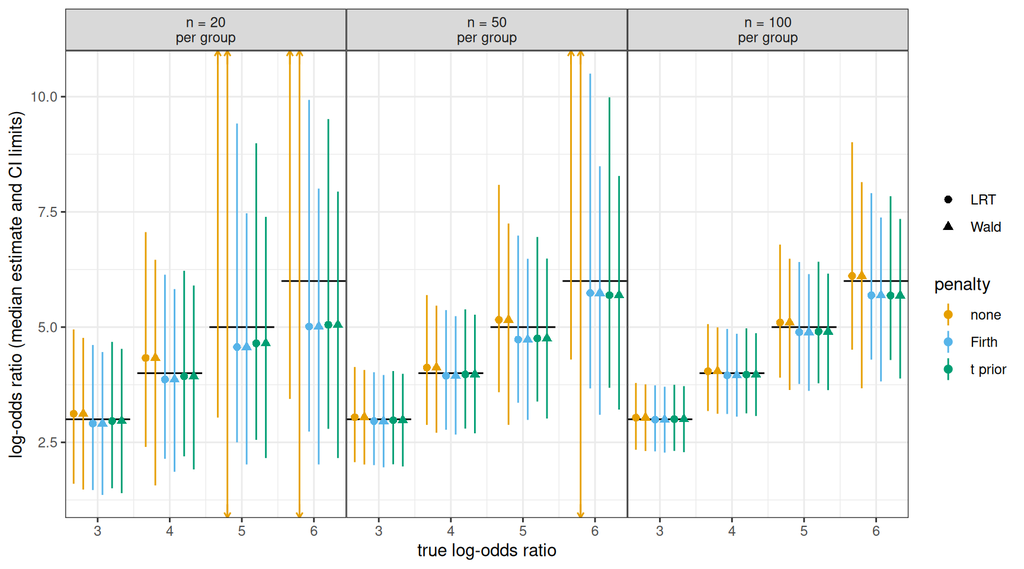

```r
med_2g <- map_dfr(3:6, exact_medians, cis = cis_2g)
plot_medians(med_2g)
```

### Coverage

One-sided coverage by tail: a well-calibrated 95% CI should have its lower limit below (and its upper limit above) the true value $\approx 97.5\%$ of the time. As a reference for how large a deviation from 0.975 is noticeable, the gray band is the 95% (Gaussian) binomial confidence interval around 0.975 for a simulation study with 2000 replicates. Colours show the penalty (none, Firth/Jeffreys, or its $t$ approximation); solid lines are profile CIs and dashed lines are Wald CIs. Comparing colours within a line type shows the effect of removing the small-sample bias; comparing line types within a colour shows the effect of the CI shape. The one-sided coverage axis is on a logit scale, with values above 0.995 drawn at 0.995. The right-hand panels show the two-sided coverage (the sum of the one-sided coverages minus 1), with the corresponding reference band around 0.95.

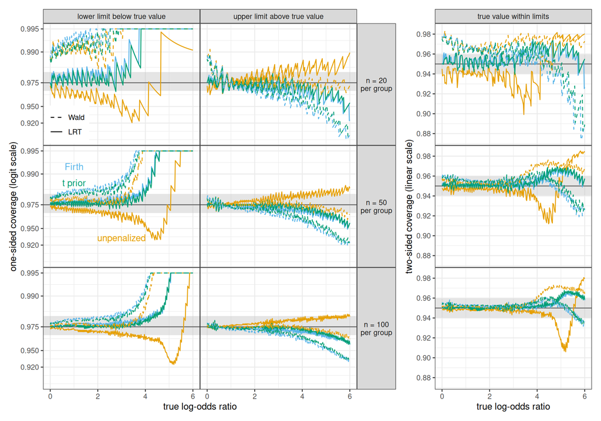

```r
## direct labels (by penalty) in the n = 50 lower-tail panel
pen_labs <- tibble(penalty = pen_levs,
                   label = c("unpenalized", "Firth", "t prior"),
                   beta = c(3, 1, 1), coverage = c(0.935, 0.992, 0.987),
                   n = 50)
plot_coverage(cov_2g, pen_labs)
```

### Low baseline probability

The same calculations with a baseline probability of 0.01 (expected 0.2, 0.5 and 1 successes in the baseline group for n = 20, 50 and 100). The CIs for each outcome don’t depend on the baseline, so only the weights change. (`wald_lrt_examples_lowp.R` does this as a stand-alone script.) The unpenalized estimate is undefined (NaN) when both groups have zero successes; these outcomes are dropped when computing the medians, but they have probability at most 0.02 (n = 20, $\beta = 3$) at the values of $\beta$ shown.

```r
p0_low <- 0.01
cov_lowp <- map_dfr(split(cis_2g, ~ n), exact_cov_n, p0 = p0_low)
med_lowp <- map_dfr(3:6, exact_medians, cis = cis_2g, p0 = p0_low)
```

The unpenalized median intervals are unbounded (in both directions for Wald and above for the profile interval) at every $\beta$ shown for n = 20 and 50; the penalized estimates fall below the true values.

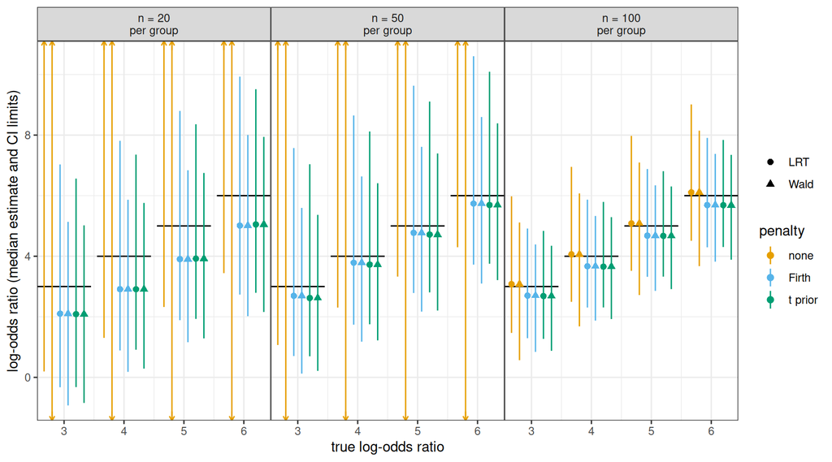

```r
plot_medians(med_lowp)
```

Coverage is strongly discrete (sawtoothed), and the lower tail is conservative almost everywhere, so the two-sided coverage is mostly determined by the upper tail. There, for $\beta \gtrsim 2$, the penalized Wald intervals are anticonservative (two-sided coverage about 0.92–0.93 for n = 50 and 100, lower for n = 20); the penalized profile intervals are much closer to nominal, and the unpenalized profile intervals are conservative. For n = 100 the unpenalized profile interval is anticonservative for small $\beta$.

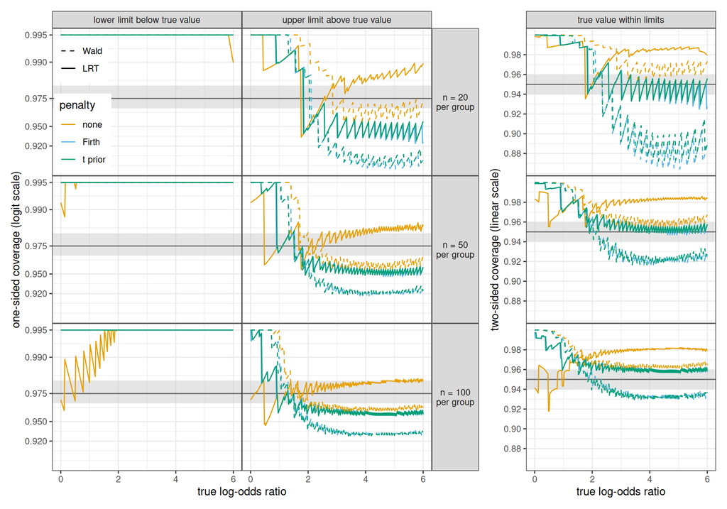

```r
plot_coverage(cov_lowp)
```

## References

Aban, Inmaculada B., Gary R. Cutter, and Nsoki Mavinga. 2009. “Inferences and Power Analysis Concerning Two Negative Binomial Distributions with an Application to MRI Lesion Counts Data.” *Computational Statistics & Data Analysis* 53 (3): 820–33. https://doi.org/10.1016/j.csda.2008.07.034.

Agresti, Alan. 2013. *Categorical Data Analysis*. 3rd ed. Hoboken, NJ: Wiley.

Fears, Thomas R., Jacques Benichou, and Mitchell H. Gail. 1996. “A Reminder of the Fallibility of the Wald Statistic.” *The American Statistician* 50 (3): 226–27. https://doi.org/10.1080/00031305.1996.10474384.

Hauck, Walter W., and Allan Donner. 1977. “Wald’s Test as Applied to Hypotheses in Logit Analysis.” *Journal of the American Statistical Association* 72 (360): 851–53. https://doi.org/10.2307/2286473.

Pawitan, Yudi. 2000. “A Reminder of the Fallibility of the Wald Statistic: Likelihood Explanation.” *The American Statistician* 54 (1): 54–56. https://doi.org/10.1080/00031305.2000.10474509.

Væth, Michael. 1985. “On the Use of Wald’s Test in Exponential Families.” *International Statistical Review* 53 (2): 199–214. https://doi.org/10.2307/1402935.

Yee, Thomas W. 2022. “On the Hauck–Donner Effect in Wald Tests: Detection, Tipping Points, and Parameter Space Characterization.” *Journal of the American Statistical Association* 117 (540): 1763–74. https://doi.org/10.1080/01621459.2021.1886936.

## Footnotes

[^1]: the non-null analogue of type-I error, i.e. when the confidence interval includes fewer or more cases than the $100 (1-\alpha) \%$ it’s supposed to